> **Tip**: Welcome to the Investigate a Dataset project! You will find tips in quoted sections like this to help organize your approach to your investigation. Once you complete this project, remove these **Tip** sections from your report before submission. First things first, you might want to double-click this Markdown cell and change the title so that it reflects your dataset and investigation.

# Project: Investigate a Dataset - [Database_No_show_appointments]

- Introduction
- Data Wrangling
- Exploratory Data Analysis
- Conclusions

## Introduction

It is an investigation of a dataset of No show appointments to analyze data to make sure the patient will attend at its appointment or not.

### Dataset Description

This dataset collects information from 100k medical appointments in Brazil. It want be to determine whether or not patients show up for their appointment. characteristics of each patient are included in each row.

1- 'ScheduledDay' tells us on what day the patient set up their appointment. 2-'Neighborhood' indicates the location of the hospital. 3-'Scholarship' indicates whether or not the patient is enrolled in Brasilian welfare program Bolsa Família. 4-'No_show' it says 'No' if the patient showed up to their appointment, and 'Yes' if they did not show up.

### Question(s) for Analysis

What factors are important for us to know in order to predict if a patient will show up for their scheduled appointment?

```python
# Use this cell to set up import statements for all of the packages that you
#   plan to use.

import numpy as np
import pandas as pd
import matplotlib.pyplot as plt
import seaborn as sns
% matplotlib inline
```

```python
# Upgrade pandas to use dataframe.explode() function.
!pip install --upgrade pandas==0.25.0
```

## Data Wrangling

> **Tip**: In this section of the report, you will load in the data, check for cleanliness, and then trim and clean your dataset for analysis. Make sure that you **document your data cleaning steps in mark-down cells precisely and justify your cleaning decisions.** In this step : loading data to check wheter the data is clean or not and check for duplicated and non null values

### General Properties

> **Tip**: You should *not* perform too many operations in each cell. Create cells freely to explore your data. One option that you can take with this project is to do a lot of explorations in an initial notebook. These don't have to be organized, but make sure you use enough comments to understand the purpose of each code cell. Then, after you're done with your analysis, create a duplicate notebook where you will trim the excess and organize your steps so that you have a flowing, cohesive report.

```python
# Load your data and print out a few lines. Perform operations to inspect data
#   types and look for instances of missing or possibly errant data.
df = pd.read_csv("noshowappointments-kagglev2-may-2016.csv")
df.head()
```

|  | PatientId | AppointmentID | Gender | ScheduledDay | AppointmentDay | Age | Neighbourhood | Scholarship | Hipertension | Diabetes | Alcoholism | Handcap | SMS_received | No-show |
| --- | --- | --- | --- | --- | --- | --- | --- | --- | --- | --- | --- | --- | --- | --- |
| 0 | 2.987250e+13 | 5642903 | F | 2016-04-29T18:38:08Z | 2016-04-29T00:00:00Z | 62 | JARDIM DA PENHA | 0 | 1 | 0 | 0 | 0 | 0 | No |
| 1 | 5.589978e+14 | 5642503 | M | 2016-04-29T16:08:27Z | 2016-04-29T00:00:00Z | 56 | JARDIM DA PENHA | 0 | 0 | 0 | 0 | 0 | 0 | No |
| 2 | 4.262962e+12 | 5642549 | F | 2016-04-29T16:19:04Z | 2016-04-29T00:00:00Z | 62 | MATA DA PRAIA | 0 | 0 | 0 | 0 | 0 | 0 | No |
| 3 | 8.679512e+11 | 5642828 | F | 2016-04-29T17:29:31Z | 2016-04-29T00:00:00Z | 8 | PONTAL DE CAMBURI | 0 | 0 | 0 | 0 | 0 | 0 | No |
| 4 | 8.841186e+12 | 5642494 | F | 2016-04-29T16:07:23Z | 2016-04-29T00:00:00Z | 56 | JARDIM DA PENHA | 0 | 1 | 1 | 0 | 0 | 0 | No |

```python
#get number of rows and columns for data
df.shape
```

```
(110527, 14)
```

```python
# check which columns have missing values with info()
df.info()
```

```
<class 'pandas.core.frame.DataFrame'>
RangeIndex: 110527 entries, 0 to 110526
Data columns (total 14 columns):
PatientId         110527 non-null float64
AppointmentID     110527 non-null int64
Gender            110527 non-null object
ScheduledDay      110527 non-null object
AppointmentDay    110527 non-null object
Age               110527 non-null int64
Neighbourhood     110527 non-null object
Scholarship       110527 non-null int64
Hipertension      110527 non-null int64
Diabetes          110527 non-null int64
Alcoholism        110527 non-null int64
Handcap           110527 non-null int64
SMS_received      110527 non-null int64
No-show           110527 non-null object
dtypes: float64(1), int64(8), object(5)
memory usage: 11.8+ MB
```

It shows that from the information function there are no null values to make sure I will use the isnull function

```python
df.isnull().sum()
```

```
PatientId         0
AppointmentID     0
Gender            0
ScheduledDay      0
AppointmentDay    0
Age               0
Neighbourhood     0
Scholarship       0
Hipertension      0
Diabetes          0
Alcoholism        0
Handcap           0
SMS_received      0
No-show           0
dtype: int64
```

So no null values in data

```python
#get description of no show data (count,mean , std, max,min,25% , 50%,75%)
df.describe()
```

|  | PatientId | AppointmentID | Age | Scholarship | Hipertension | Diabetes | Alcoholism | Handcap | SMS_received |
| --- | --- | --- | --- | --- | --- | --- | --- | --- | --- |
| count | 1.105270e+05 | 1.105270e+05 | 110527.000000 | 110527.000000 | 110527.000000 | 110527.000000 | 110527.000000 | 110527.000000 | 110527.000000 |
| mean | 1.474963e+14 | 5.675305e+06 | 37.088874 | 0.098266 | 0.197246 | 0.071865 | 0.030400 | 0.022248 | 0.321026 |
| std | 2.560949e+14 | 7.129575e+04 | 23.110205 | 0.297675 | 0.397921 | 0.258265 | 0.171686 | 0.161543 | 0.466873 |
| min | 3.921784e+04 | 5.030230e+06 | -1.000000 | 0.000000 | 0.000000 | 0.000000 | 0.000000 | 0.000000 | 0.000000 |
| 25% | 4.172614e+12 | 5.640286e+06 | 18.000000 | 0.000000 | 0.000000 | 0.000000 | 0.000000 | 0.000000 | 0.000000 |
| 50% | 3.173184e+13 | 5.680573e+06 | 37.000000 | 0.000000 | 0.000000 | 0.000000 | 0.000000 | 0.000000 | 0.000000 |
| 75% | 9.439172e+13 | 5.725524e+06 | 55.000000 | 0.000000 | 0.000000 | 0.000000 | 0.000000 | 0.000000 | 1.000000 |
| max | 9.999816e+14 | 5.790484e+06 | 115.000000 | 1.000000 | 1.000000 | 1.000000 | 1.000000 | 4.000000 | 1.000000 |

From describe function I noticed that : The average age is about 37 and there is a -1 age which is a mistake number max-age of patients:115 The average of patients who received SMS is 0.3 and it is really small so there is a problem with the SMS system

```python
mistake_age = df.query("Age==-1")
mistake_age
```

|  | PatientId | AppointmentID | Gender | ScheduledDay | AppointmentDay | Age | Neighbourhood | Scholarship | Hipertension | Diabetes | Alcoholism | Handcap | SMS_received | No-show |
| --- | --- | --- | --- | --- | --- | --- | --- | --- | --- | --- | --- | --- | --- | --- |
| 99832 | 4.659432e+14 | 5775010 | F | 2016-06-06T08:58:13Z | 2016-06-06T00:00:00Z | -1 | ROMÃO | 0 | 0 | 0 | 0 | 0 | 0 | No |

It is noticed that we have one row of data that includes -1 for age and I will drop it in the data cleaning

```python
# check for duplicates in the data
sum(df.duplicated())
```

```
0
```

The is no duplicated values in the data

### Data Cleaning

> **Tip**: Make sure that you keep your reader informed on the steps that you are taking in your investigation. Follow every code cell, or every set of related code cells, with a markdown cell to describe to the reader what was found in the preceding cell(s). Try to make it so that the reader can then understand what they will be seeing in the following cell(s).

```python
#drop  row of age that included -1
df.drop(index=99832 , inplace=True)
```

```python
#make sure this row is dropped
df.describe()
```

|  | PatientId | AppointmentID | Age | Scholarship | Hipertension | Diabetes | Alcoholism | Handcap | SMS_received |
| --- | --- | --- | --- | --- | --- | --- | --- | --- | --- |
| count | 1.105260e+05 | 1.105260e+05 | 110526.000000 | 110526.000000 | 110526.000000 | 110526.000000 | 110526.000000 | 110526.000000 | 110526.000000 |
| mean | 1.474934e+14 | 5.675304e+06 | 37.089219 | 0.098266 | 0.197248 | 0.071865 | 0.030400 | 0.022248 | 0.321029 |
| std | 2.560943e+14 | 7.129544e+04 | 23.110026 | 0.297676 | 0.397923 | 0.258266 | 0.171686 | 0.161543 | 0.466874 |
| min | 3.921784e+04 | 5.030230e+06 | 0.000000 | 0.000000 | 0.000000 | 0.000000 | 0.000000 | 0.000000 | 0.000000 |
| 25% | 4.172536e+12 | 5.640285e+06 | 18.000000 | 0.000000 | 0.000000 | 0.000000 | 0.000000 | 0.000000 | 0.000000 |
| 50% | 3.173184e+13 | 5.680572e+06 | 37.000000 | 0.000000 | 0.000000 | 0.000000 | 0.000000 | 0.000000 | 0.000000 |
| 75% | 9.438963e+13 | 5.725523e+06 | 55.000000 | 0.000000 | 0.000000 | 0.000000 | 0.000000 | 0.000000 | 1.000000 |
| max | 9.999816e+14 | 5.790484e+06 | 115.000000 | 1.000000 | 1.000000 | 1.000000 | 1.000000 | 4.000000 | 1.000000 |

```python
#rename No-show to No_show
#correct spelling mistake for Hipertension to Hypertension
#correct spelling mistake for  Handcap to Handicap
df.rename(columns={"No-show":"No_show","Hipertension":"Hypertension","Handcap":"Handicap"},inplace=True)
```

```python
df.head()
```

|  | PatientId | AppointmentID | Gender | ScheduledDay | AppointmentDay | Age | Neighbourhood | Scholarship | Hypertension | Diabetes | Alcoholism | Handicap | SMS_received | No_show |
| --- | --- | --- | --- | --- | --- | --- | --- | --- | --- | --- | --- | --- | --- | --- |
| 0 | 2.987250e+13 | 5642903 | F | 2016-04-29T18:38:08Z | 2016-04-29T00:00:00Z | 62 | JARDIM DA PENHA | 0 | 1 | 0 | 0 | 0 | 0 | No |
| 1 | 5.589978e+14 | 5642503 | M | 2016-04-29T16:08:27Z | 2016-04-29T00:00:00Z | 56 | JARDIM DA PENHA | 0 | 0 | 0 | 0 | 0 | 0 | No |
| 2 | 4.262962e+12 | 5642549 | F | 2016-04-29T16:19:04Z | 2016-04-29T00:00:00Z | 62 | MATA DA PRAIA | 0 | 0 | 0 | 0 | 0 | 0 | No |
| 3 | 8.679512e+11 | 5642828 | F | 2016-04-29T17:29:31Z | 2016-04-29T00:00:00Z | 8 | PONTAL DE CAMBURI | 0 | 0 | 0 | 0 | 0 | 0 | No |
| 4 | 8.841186e+12 | 5642494 | F | 2016-04-29T16:07:23Z | 2016-04-29T00:00:00Z | 56 | JARDIM DA PENHA | 0 | 1 | 1 | 0 | 0 | 0 | No |

```python
#drop unused columns
df.drop(columns=["PatientId","AppointmentID","ScheduledDay","AppointmentDay"],axis=1,inplace=True)
df.head()
```

|  | Gender | Age | Neighbourhood | Scholarship | Hypertension | Diabetes | Alcoholism | Handicap | SMS_received | No_show |
| --- | --- | --- | --- | --- | --- | --- | --- | --- | --- | --- |
| 0 | F | 62 | JARDIM DA PENHA | 0 | 1 | 0 | 0 | 0 | 0 | No |
| 1 | M | 56 | JARDIM DA PENHA | 0 | 0 | 0 | 0 | 0 | 0 | No |
| 2 | F | 62 | MATA DA PRAIA | 0 | 0 | 0 | 0 | 0 | 0 | No |
| 3 | F | 8 | PONTAL DE CAMBURI | 0 | 0 | 0 | 0 | 0 | 0 | No |
| 4 | F | 56 | JARDIM DA PENHA | 0 | 1 | 1 | 0 | 0 | 0 | No |

## Exploratory Data Analysis

> **Tip**: Now that you've trimmed and cleaned your data, you're ready to move on to exploration. **Compute statistics** and **create visualizations** with the goal of addressing the research questions that you posed in the Introduction section. You should compute the relevant statistics throughout the analysis when an inference is made about the data. Note that at least two or more kinds of plots should be created as part of the exploration, and you must compare and show trends in the varied visualizations.

> **Tip**: - Investigate the stated question(s) from multiple angles. It is recommended that you be systematic with your approach. Look at one variable at a time, and then follow it up by looking at relationships between variables. You should explore at least three variables in relation to the primary question. This can be an exploratory relationship between three variables of interest, or looking at how two independent variables relate to a single dependent variable of interest. Lastly, you should perform both single-variable (1d) and multiple-variable (2d) explorations.

### Research Question 1 (What are the factors that affect patients' attendance)

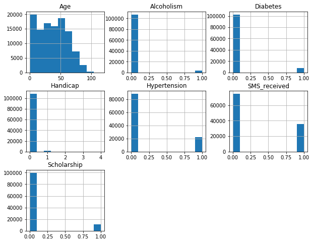

```python
df.hist(figsize=(10,8));
```

```python
#use  new variables such as show_patient and noshow_patient to be more accurate
# No meaning the patient is attending at its appointment
#Yes meaning the patient is not attending at its appointment
show_patient= df.No_show=="No"
noshow_patient=df.No_show=="Yes"
```

```python
df[show_patient].count()
```

```
Gender           88207
Age              88207
Neighbourhood    88207
Scholarship      88207
Hypertension     88207
Diabetes         88207
Alcoholism       88207
Handicap         88207
SMS_received     88207
No_show          88207
dtype: int64
```

```python
df[noshow_patient].count()
```

```
Gender           22319
Age              22319
Neighbourhood    22319
Scholarship      22319
Hypertension     22319
Diabetes         22319
Alcoholism       22319
Handicap         22319
SMS_received     22319
No_show          22319
dtype: int64
```

Most patients attend their appointments

```python
df[show_patient].mean()
```

```
Age             37.790504
Scholarship      0.093904
Hypertension     0.204394
Diabetes         0.073838
Alcoholism       0.030417
Handicap         0.022742
SMS_received     0.291337
dtype: float64
```

```python
df[noshow_patient].mean()
```

```
Age             34.317667
Scholarship      0.115507
Hypertension     0.169004
Diabetes         0.064071
Alcoholism       0.030333
Handicap         0.020297
SMS_received     0.438371
dtype: float64
```

The average range of patients who attend their appointment is 37 and not attend is about 34 patients who attend their appointment who received SMS is less than those who received

# Does the age affect patients' attendance?

```python
df["Age"].mean()
```

```
37.089218826339504
```

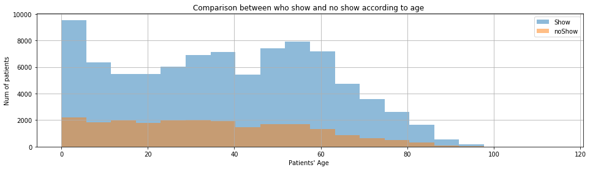

```python
def fact_show (df ,c_name,show,noshow):
    plt.figure(figsize=[16,4])
    df[c_name][show].hist(alpha=0.5, bins=20, label='Show')
    df[c_name][noshow].hist(alpha=0.5, bins=20, label='noShow')
    plt.legend();
    plt.title('Comparison between who show and no show according to age ')
    plt.xlabel("Patients' Age ")
    plt.ylabel('Num of patients');

fact_show (df,"Age",show_patient,noshow_patient)
```

# Does Gender affect patients' attendance?

```python
df["Gender"].value_counts()
```

```
F    71839
M    38687
Name: Gender, dtype: int64
```

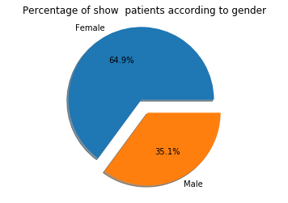

```python
def fact_show (df ,c_name,show,noshow):

    count_show=df[c_name][show].value_counts()

    mylabels = ["Female","Male"]

    myexplode = [0.2, 0]
    plt.pie(count_show, autopct='%1.1f%%',explode=myexplode ,labels =mylabels,shadow = True)
    plt.title('Percentage of show  patients according to gender' )
    plt.axis('equal')
    plt.show()

fact_show (df,"Gender",show_patient,noshow_patient)
```

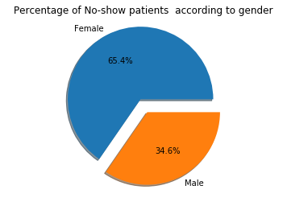

```python
def fact_noshow (df ,c_name,show,noshow):

    count_show=df[c_name][noshow].value_counts()

    mylabels = ["Female","Male"]

    myexplode = [0.2, 0]
    plt.pie(count_show, autopct='%1.1f%%',explode=myexplode ,labels =mylabels,shadow = True)
    plt.title('Percentage of No-show patients  according to gender')
    plt.axis('equal')
    plt.show()

fact_noshow (df,"Gender",show_patient,noshow_patient)
```

The two pie charts show that the percentage of females and males who attend and do not attend their appointment seems the same so the gender does not affect patients' attends

# Does the Scholarship affect patients' attendance?

```python
df["Scholarship"].value_counts()
```

```
0    99665
1    10861
Name: Scholarship, dtype: int64
```

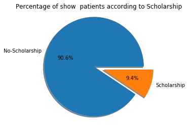

```python
def fact_show (df ,c_name,show,noshow):

    count_show=df[c_name][show].value_counts()

    mylabels = ["No-Scholarship","Scholarship"]

    myexplode = [0.2, 0]
    plt.pie(count_show, autopct='%1.1f%%',explode=myexplode ,labels =mylabels,shadow = True)
    plt.title('Percentage of show  patients according to Scholarship' )
    plt.axis('equal')
    plt.show()

fact_show (df,"Scholarship",show_patient,noshow_patient)
```

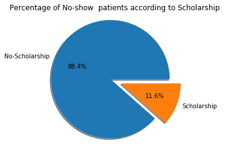

```python
def fact_noshow (df ,c_name,show,noshow):

    count_show=df[c_name][noshow].value_counts()

    mylabels = ["No-Scholarship","Scholarship"]

    myexplode = [0.2, 0]
    plt.pie(count_show, autopct='%1.1f%%',explode=myexplode ,labels =mylabels,shadow = True)
    plt.title('Percentage of No-show  patients according to Scholarship ' )
    plt.axis('equal')
    plt.show()

fact_noshow (df,"Scholarship",show_patient,noshow_patient)
```

The two pie charts show that the percentage of patients who have a Scholarship and who does not have Scholarship do not affect their appointment seems the same so the Scholarship does not affect patients' attend

# Does the Hypertension affects the patients' attendance

```python
df[noshow_patient]["Hypertension"].value_counts()
```

```
0    18547
1     3772
Name: Hypertension, dtype: int64
```

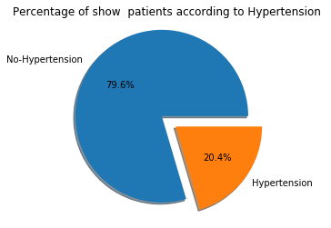

```python
def fact_show (df ,c_name,show,noshow):

    count_show=df[c_name][show].value_counts()

    mylabels = ["No-Hypertension ","Hypertension "]

    myexplode = [0.2, 0]
    plt.pie(count_show, autopct='%1.1f%%',explode=myexplode ,labels =mylabels,shadow = True)
    plt.title('Percentage of show  patients according to Hypertension ' )
    plt.axis('equal')
    plt.show()

fact_show (df,"Hypertension",show_patient,noshow_patient)
```

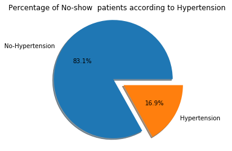

```python
def fact_noshow (df ,c_name,show,noshow):

    count_show=df[c_name][noshow].value_counts()

    mylabels = ["No-Hypertension ","Hypertension "]

    myexplode = [0.2, 0]
    plt.pie(count_show, autopct='%1.1f%%',explode=myexplode ,labels =mylabels,shadow = True)
    plt.title('Percentage of No-show  patients according to Hypertension ' )
    plt.axis('equal')
    plt.show()

fact_noshow (df,"Hypertension",show_patient,noshow_patient)
```

The two pie charts show that the percentage of patients who have Hypertension and who does not have Hypertension do not affect their appointment so the Hypertensiondoes do not affect patients' attend

# Does the Diabetes affects the patients' attendance

```python
df["Diabetes"].value_counts()
```

```
0    102583
1      7943
Name: Diabetes, dtype: int64
```

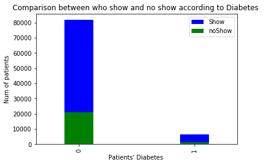

```python
def fact_show (df ,c_name,show,noshow):

    df[c_name][show].value_counts().plot(kind="bar",color="b",width = 0.25,label='Show');
    df[c_name][noshow].value_counts().plot(kind="bar",color="g",width = 0.25,label='noShow');
    plt.legend();
    plt.title('Comparison between who show and no show according to Diabetes ')
    plt.xlabel("Patients' Diabetes ")
    plt.ylabel('Num of patients');

fact_show (df,"Diabetes",show_patient,noshow_patient)
```

Diabetes does not affect patients' attendance

# Does they correlate with patients' age and patients' diabetes?

```python
df[show_patient].groupby("Diabetes").mean()["Age"]
```

```
Diabetes
0    35.887544
1    61.659757
Name: Age, dtype: float64
```

```python
df[noshow_patient].groupby("Diabetes").mean()["Age"]
```

```
Diabetes
0    32.555125
1    60.064336
Name: Age, dtype: float64
```

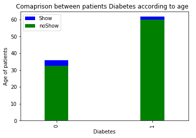

```python
df[show_patient].groupby("Diabetes").mean()["Age"].plot(kind="bar",color = 'b', width = 0.25, label='Show')
df[noshow_patient].groupby("Diabetes").mean()["Age"].plot(kind="bar", color = 'g', width = 0.25,label='noShow')
plt.legend();
plt.title('Comaprison between patients Diabetes according to age  ')
plt.xlabel(" Diabetes ")
plt.ylabel('Age of patients');
```

5-Note that diabetes does not affect the patients' attendance

# Does the Alcoholism affects the patients' attendance

```python
df["Alcoholism"].value_counts()
```

```
0    107166
1      3360
Name: Alcoholism, dtype: int64
```

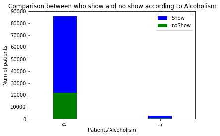

```python
def fact_show (df ,c_name,show,noshow):

    df[c_name][show].value_counts().plot(kind="bar",color="b",width = 0.25,label='Show');
    df[c_name][noshow].value_counts().plot(kind="bar",color="g",width = 0.25,label='noShow');
    plt.legend();
    plt.title('Comparison between who show and no show according to Alcoholism')
    plt.xlabel("Patients'Alcoholism ")
    plt.ylabel('Num of patients');

fact_show (df,"Alcoholism",show_patient,noshow_patient)
```

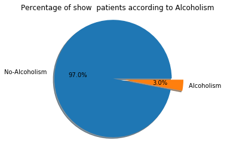

```python
def fact_show (df ,c_name,show,noshow):

    count_show=df[c_name][show].value_counts()

    mylabels = ["No-Alcoholism ","Alcoholism "]

    myexplode = [0.2, 0]
    plt.pie(count_show, autopct='%1.1f%%',explode=myexplode ,labels =mylabels,shadow = True)
    plt.title('Percentage of show  patients according to Alcoholism ' )
    plt.axis('equal')
    plt.show()

fact_show (df,"Alcoholism",show_patient,noshow_patient)
```

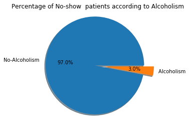

```python
def fact_noshow (df ,c_name,show,noshow):

    count_show=df[c_name][noshow].value_counts()

    mylabels = ["No-Alcoholism ","Alcoholism "]

    myexplode = [0.2, 0]
    plt.pie(count_show, autopct='%1.1f%%',explode=myexplode ,labels =mylabels,shadow = True)
    plt.title('Percentage of No-show  patients according to Alcoholism  ' )
    plt.axis('equal')
    plt.show()

fact_noshow (df,"Alcoholism",show_patient,noshow_patient)
```

# Does the Handicap affects the patients' attendance

```python
df["Handicap"].value_counts()
```

```
0    108285
1      2042
2       183
3        13
4         3
Name: Handicap, dtype: int64
```

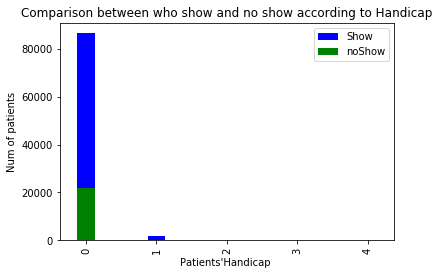

```python
def fact_show (df ,c_name,show,noshow):

    df[c_name][show].value_counts().plot(kind="bar",color="b",width = 0.25,label='Show');
    df[c_name][noshow].value_counts().plot(kind="bar",color="g",width = 0.25,label='noShow');
    plt.legend();
    plt.title('Comparison between who show and no show according to Handicap')
    plt.xlabel("Patients'Handicap ")
    plt.ylabel('Num of patients');

fact_show (df,"Handicap",show_patient,noshow_patient)
```

Handicap does not asffect patients' attend

# Does the SMS Received affect the patients' attendance?

```python
df["SMS_received"].value_counts()
```

```
0    75044
1    35482
Name: SMS_received, dtype: int64
```

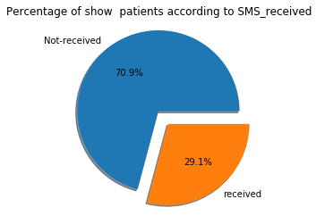

```python
def fact_show (df ,c_name,show,noshow):

    count_show=df[c_name][show].value_counts()

    mylabels = ["Not-received ","received"]

    myexplode = [0.2, 0]
    plt.pie(count_show, autopct='%1.1f%%',explode=myexplode ,labels =mylabels,shadow = True)
    plt.title('Percentage of show  patients according to SMS_received  ' )
    plt.axis('equal')
    plt.show()

fact_show (df,"SMS_received",show_patient,noshow_patient)
```

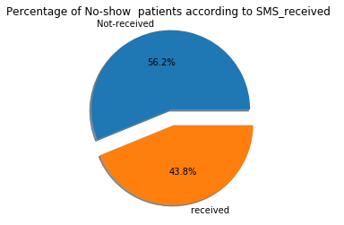

```python
def fact_noshow (df ,c_name,show,noshow):

    count_show=df[c_name][noshow].value_counts()

    mylabels = ["Not-received","received "]

    myexplode = [0.2, 0]
    plt.pie(count_show, autopct='%1.1f%%',explode=myexplode ,labels =mylabels,shadow = True)
    plt.title('Percentage of No-show  patients according to SMS_received  ' )
    plt.axis('equal')
    plt.show()

fact_noshow (df,"SMS_received",show_patient,noshow_patient)
```

# Does the Neighbourhood affects the patients' attend

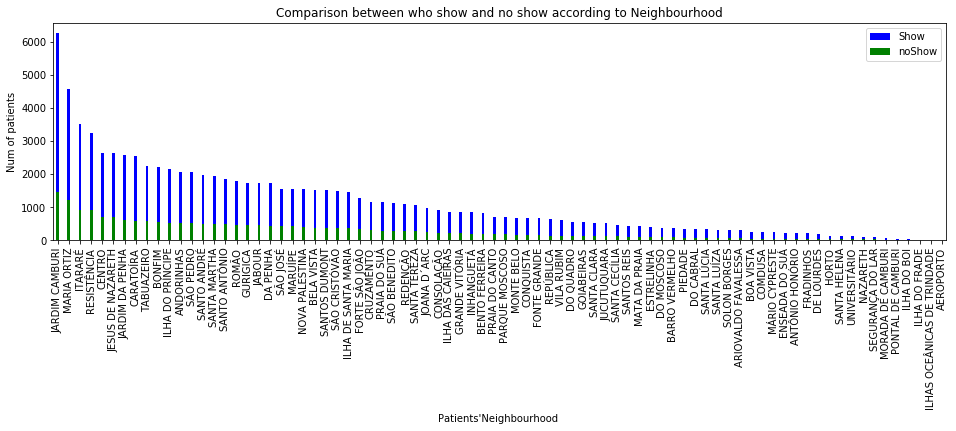

```python
def fact_show (df ,c_name,show,noshow):
    plt.figure(figsize=[16,4])
    df[c_name][show].value_counts().plot(kind="bar",color="b",width = 0.25,label='Show');
    df[c_name][noshow].value_counts().plot(kind="bar",color="g",width = 0.25,label='noShow');
    plt.legend();
    plt.title('Comparison between who show and no show according to Neighbourhood')
    plt.xlabel("Patients'Neighbourhood ")
    plt.ylabel('Num of patients');

fact_show (df,"Neighbourhood",show_patient,noshow_patient)
```

# Research Question 2 (What is the percentage of patients who show and No-show)

```python
count=df["No_show"].value_counts()
print(count)
```

```
No     88207
Yes    22319
Name: No_show, dtype: int64
```

```python
percentage_show=(count[0]/count.sum())*100
print(percentage_show)
```

```
79.80656135208005
```

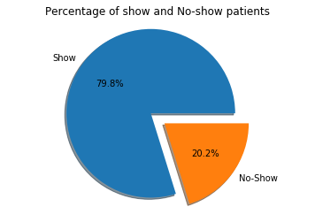

```python
#draw a pie chart to get the percentage of the show and no show patients
def percentage_show  (df):

    count_show=df["No_show"].value_counts()

    mylabels = ["Show","No-Show"]

    myexplode = [0.2, 0]
    plt.pie(count_show, autopct='%1.1f%%',explode=myexplode ,labels =mylabels,shadow = True)
    plt.title('Percentage of show and No-show patients')
    plt.axis('equal')
    plt.show()
percentage_show (df)
```

The pie chart shows that about 79.8 % of patients will attend their appointment

## Conclusions

1-Age affects patients' show from age zer0 to less than 10 is greater than any age followed by the age between 37 to 55 and then the less show for older people are the least showing from age and more

2-The patients who do not receive and show are greater than those who received and show 3-Need to check the SMS system 4-The neighborhood has a great effect on the patients' show ,the (JARDIM CAMBURi) is the most high-level neighborhood of show

# Limitation:

Could not get the correlation between show and no show and charcterastics such as (Scholarship ,Hypertension ,Diabetes Alcoholism, Handicap)

## Submitting your Project

> **Tip**: Before you submit your project, you need to create a .html or .pdf version of this notebook in the workspace here. To do that, run the code cell below. If it worked correctly, you should get a return code of 0, and you should see the generated .html file in the workspace directory (click on the orange Jupyter icon in the upper left).

> **Tip**: Alternatively, you can download this report as .html via the **File** > **Download as** submenu, and then manually upload it into the workspace directory by clicking on the orange Jupyter icon in the upper left, then using the Upload button.

> **Tip**: Once you've done this, you can submit your project by clicking on the "Submit Project" button in the lower right here. This will create and submit a zip file with this .ipynb doc and the .html or .pdf version you created. Congratulations!

```python
from subprocess import call
call(['python', '-m', 'nbconvert', 'Investigate_a_Dataset.ipynb'])
```

```
0
```